# R Notebook

```r
getwd()
```

```
[1] "/Users/jadesolaakinola/Documents/0. EDUCATION/MASTERS/3. TERM 3/Analytical Modelling/Group Project"
```

```r
library(tidyverse)
library(lubridate)
traffic_crashes <- read.csv("./Data/Traffic_Crashes.csv")
```

```r
unlist(lapply(traffic_crashes,class))
```

```
              CRASH_RECORD_ID              CRASH_DATE_EST_I                    CRASH_DATE            POSTED_SPEED_LIMIT
                  "character"                   "character"                   "character"                     "integer"
       TRAFFIC_CONTROL_DEVICE              DEVICE_CONDITION             WEATHER_CONDITION            LIGHTING_CONDITION
                  "character"                   "character"                   "character"                   "character"
             FIRST_CRASH_TYPE               TRAFFICWAY_TYPE                      LANE_CNT                     ALIGNMENT
                  "character"                   "character"                     "integer"                   "character"
         ROADWAY_SURFACE_COND                   ROAD_DEFECT                   REPORT_TYPE                    CRASH_TYPE
                  "character"                   "character"                   "character"                   "character"
       INTERSECTION_RELATED_I            NOT_RIGHT_OF_WAY_I                 HIT_AND_RUN_I                        DAMAGE
                  "character"                   "character"                   "character"                   "character"
         DATE_POLICE_NOTIFIED       PRIM_CONTRIBUTORY_CAUSE        SEC_CONTRIBUTORY_CAUSE                     STREET_NO
                  "character"                   "character"                   "character"                     "integer"
             STREET_DIRECTION                   STREET_NAME            BEAT_OF_OCCURRENCE                PHOTOS_TAKEN_I
                  "character"                   "character"                     "integer"                   "character"
           STATEMENTS_TAKEN_I                     DOORING_I                   WORK_ZONE_I                WORK_ZONE_TYPE
                  "character"                   "character"                   "character"                   "character"
            WORKERS_PRESENT_I                     NUM_UNITS            MOST_SEVERE_INJURY                INJURIES_TOTAL
                  "character"                     "integer"                   "character"                     "integer"
               INJURIES_FATAL       INJURIES_INCAPACITATING   INJURIES_NON_INCAPACITATING INJURIES_REPORTED_NOT_EVIDENT
                    "integer"                     "integer"                     "integer"                     "integer"
       INJURIES_NO_INDICATION              INJURIES_UNKNOWN                    CRASH_HOUR             CRASH_DAY_OF_WEEK
                    "integer"                     "integer"                     "integer"                     "integer"
                  CRASH_MONTH                      LATITUDE                     LONGITUDE                      LOCATION
                    "integer"                     "numeric"                     "numeric"                   "character"
```

```r
character_variables <- c(
  "CRASH_RECORD_ID", "CRASH_DATE_EST_I", "STREET_NO",
  "STREET_NAME", "BEAT_OF_OCCURRENCE"
)
```

```r
traffic_crashes <- traffic_crashes %>%
  mutate(across(all_of(factor_variables), as.factor)) %>%
  mutate(across(all_of(character_variables), as.character))
```

```r
#Overview of all variables
summary <- summary(traffic_crashes)
```

```r
#Numeric Variables - Summary Statistics
summary_results <- list()

for (var in names(traffic_crashes)) {
  if (is.numeric(traffic_crashes[[var]])) {
    var_summary <- round(as.numeric(summary(traffic_crashes[[var]])), digits = 2)
    summary_results[[var]] <- as.numeric(var_summary)
  }
}
numeric_summary <- do.call(rbind, summary_results)
colnames(numeric_summary) <- c("Min.", "Q1",  "Median",  "Mean", "Q3", "Max", "NA Count")
```

```r
numeric_summary <- as.data.frame(numeric_summary)
```

```r
numeric_summary <- numeric_summary %>%
  mutate(
    IQR = Q3 - Q1
  )
```

```r
#Factor Variables - Summary Statistics
factor_results <- list()

for (var in names(traffic_crashes)) {
  if (is.factor(traffic_crashes[[var]])) {
    num_levels <- length(unique(traffic_crashes[[var]]))
    level_counts <- table(traffic_crashes[[var]])
    most_frequent_level <- names(which.max(level_counts))
    most_frequent_count <- level_counts[most_frequent_level]
    num_missing <- sum(is.na(traffic_crashes[[var]]))

    factor_results[[var]] <- c(
      num_levels,
      most_frequent_level,
      most_frequent_count,
      num_missing
    )
  }
}

factor_summary <- do.call(rbind, factor_results)

colnames(factor_summary) <- c("Unique", "Most Frequent",  "Most Frequent Count", "NA Count")
```

```r
factor_summary <- as.data.frame(factor_summary)
```

```r
#Character Variables - Summary Statistics
character_results <- list()

for (var in names(traffic_crashes)) {
  if (is.character(traffic_crashes[[var]])) {

    unique_count <- length(unique(traffic_crashes[[var]]))
    most_frequent_value <- names(sort(table(traffic_crashes[[var]]), decreasing = TRUE))[1]
    most_frequent_freq <- max(table(traffic_crashes[[var]]))
    num_missing <- sum(is.na(traffic_crashes[[var]]))

    character_results[[var]] <- c(
      unique_count,
      most_frequent_value,
      most_frequent_freq,
      num_missing
    )
  }
}

character_summary <- do.call(rbind, character_results)

colnames(character_summary) <- c("Unique", "Most Frequent","Most Frequent Count","NA Count")
```

```r
character_summary <- as.data.frame(character_summary)
```

```r
char_fact <- rbind(factor_summary,character_summary)
```

```r
char_fact
```

|  | Unique | Most Frequent | Most Frequent Count | NA Count |
| --- | --- | --- | --- | --- |
| TRAFFIC_CONTROL_DEVICE | 19 | NO CONTROLS | 457919 | 0 |
| DEVICE_CONDITION | 8 | NO CONTROLS | 463280 | 0 |
| WEATHER_CONDITION | 12 | CLEAR | 631035 | 0 |
| LIGHTING_CONDITION | 6 | DAYLIGHT | 515270 | 0 |
| FIRST_CRASH_TYPE | 18 | PARKED MOTOR VEHICLE | 187175 | 0 |
| TRAFFICWAY_TYPE | 20 | NOT DIVIDED | 350038 | 0 |
| ALIGNMENT | 6 | STRAIGHT AND LEVEL | 785569 | 0 |
| ROADWAY_SURFACE_COND | 7 | DRY | 593642 | 0 |
| ROAD_DEFECT | 7 | NO DEFECTS | 648240 | 0 |
| REPORT_TYPE | 4 | NOT ON SCENE (DESK REPORT) | 441410 | 0 |

[output cut: 26 more lines]

```r
numeric_summary
```

|  | Min. | Q1 | Median | Mean | Q3 | Max | NA Count | IQR |
| --- | --- | --- | --- | --- | --- | --- | --- | --- |
| POSTED_SPEED_LIMIT | 0.00 | 30.00 | 30.00 | 28.40 | 30.00 | 99.00 | 0 | 0.00 |
| LANE_CNT | 0.00 | 2.00 | 2.00 | 13.33 | 4.00 | 1191625.00 | 606189 | 2.00 |
| NUM_UNITS | 1.00 | 2.00 | 2.00 | 2.03 | 2.00 | 18.00 | 1 | 0.00 |
| INJURIES_TOTAL | 0.00 | 0.00 | 0.00 | 0.19 | 0.00 | 21.00 | 1761 | 0.00 |
| INJURIES_FATAL | 0.00 | 0.00 | 0.00 | 0.00 | 0.00 | 4.00 | 1761 | 0.00 |
| INJURIES_INCAPACITATING | 0.00 | 0.00 | 0.00 | 0.02 | 0.00 | 10.00 | 1761 | 0.00 |
| INJURIES_NON_INCAPACITATING | 0.00 | 0.00 | 0.00 | 0.11 | 0.00 | 21.00 | 1761 | 0.00 |
| INJURIES_REPORTED_NOT_EVIDENT | 0.00 | 0.00 | 0.00 | 0.06 | 0.00 | 15.00 | 1761 | 0.00 |
| INJURIES_NO_INDICATION | 0.00 | 1.00 | 2.00 | 2.00 | 2.00 | 61.00 | 1761 | 1.00 |
| INJURIES_UNKNOWN | 0.00 | 0.00 | 0.00 | 0.00 | 0.00 | 0.00 | 1761 | 0.00 |

[output cut: 2 more lines]

```r
names(traffic_crashes)
```

```
 [1] "CRASH_RECORD_ID"               "CRASH_DATE_EST_I"              "CRASH_DATE"
 [4] "POSTED_SPEED_LIMIT"            "TRAFFIC_CONTROL_DEVICE"        "DEVICE_CONDITION"
 [7] "WEATHER_CONDITION"             "LIGHTING_CONDITION"            "FIRST_CRASH_TYPE"
[10] "TRAFFICWAY_TYPE"               "LANE_CNT"                      "ALIGNMENT"
[13] "ROADWAY_SURFACE_COND"          "ROAD_DEFECT"                   "REPORT_TYPE"
[16] "CRASH_TYPE"                    "INTERSECTION_RELATED_I"        "NOT_RIGHT_OF_WAY_I"
[19] "HIT_AND_RUN_I"                 "DAMAGE"                        "DATE_POLICE_NOTIFIED"
[22] "PRIM_CONTRIBUTORY_CAUSE"       "SEC_CONTRIBUTORY_CAUSE"        "STREET_NO"
[25] "STREET_DIRECTION"              "STREET_NAME"                   "BEAT_OF_OCCURRENCE"
[28] "PHOTOS_TAKEN_I"                "STATEMENTS_TAKEN_I"            "DOORING_I"
[31] "WORK_ZONE_I"                   "WORK_ZONE_TYPE"                "WORKERS_PRESENT_I"
[34] "NUM_UNITS"                     "MOST_SEVERE_INJURY"            "INJURIES_TOTAL"
[37] "INJURIES_FATAL"                "INJURIES_INCAPACITATING"       "INJURIES_NON_INCAPACITATING"
[40] "INJURIES_REPORTED_NOT_EVIDENT" "INJURIES_NO_INDICATION"        "INJURIES_UNKNOWN"
[43] "CRASH_HOUR"                    "CRASH_DAY_OF_WEEK"             "CRASH_MONTH"
[46] "LATITUDE"                      "LONGITUDE"                     "LOCATION"
```

#EDA

#parsing the dates

```r
traffic_crashes1 <- read.csv("./Data/Traffic_Crashes.csv")

traffic_crashes1 <- traffic_crashes1 %>% mutate(
  date = parse_date_time(CRASH_DATE, orders = "%m/%d/%Y %I:%M:%s %p"),
  year = str_match(date,  "(\\d+)")[,-2],
  time = str_match(date, "\\d+-\\d+-\\d+ (\\d+:\\d+:\\d+)")[,2]) %>%
  select(CRASH_DATE, date, year, time, everything())
traffic_crashes1
```

| CRASH_DATE | date | year | time | CRASH_RECORD_ID | CRASH_DATE_EST_I | POSTED_SPEED_LIMIT | TRAFFIC_CONTROL_DEVICE | DEVICE_CONDITION | WEATHER_CONDITION | LIGHTING_CONDITION | FIRST_CRASH_TYPE | TRAFFICWAY_TYPE | LANE_CNT | ALIGNMENT | ROADWAY_SURFACE_COND | ROAD_DEFECT | REPORT_TYPE | CRASH_TYPE | INTERSECTION_RELATED_I | NOT_RIGHT_OF_WAY_I | HIT_AND_RUN_I | DAMAGE | DATE_POLICE_NOTIFIED | PRIM_CONTRIBUTORY_CAUSE | SEC_CONTRIBUTORY_CAUSE | STREET_NO | STREET_DIRECTION | STREET_NAME | BEAT_OF_OCCURRENCE | … |
| --- | --- | --- | --- | --- | --- | --- | --- | --- | --- | --- | --- | --- | --- | --- | --- | --- | --- | --- | --- | --- | --- | --- | --- | --- | --- | --- | --- | --- | --- | --- |
| 09/05/2023 07:05:00 PM | 2023-09-05 19:05:00 | 2023 | 19:05:00 | 23a79931ef555d54118f64dc9be2cf2dbf59636ce253f7a1179c4a1c091442a6eeab8352220c7c56ca1ff7c4b4b0fc345c74e3e85ecb9d43deeb66b5f803d4a0 |  | 30 | TRAFFIC SIGNAL | FUNCTIONING PROPERLY | CLEAR | DUSK | ANGLE | FIVE POINT, OR MORE | NA | STRAIGHT AND LEVEL | DRY | NO DEFECTS | ON SCENE | INJURY AND / OR TOW DUE TO CRASH | Y |  |  | OVER $1,500 | 09/05/2023 07:05:00 PM | UNABLE TO DETERMINE | NOT APPLICABLE | 5500 | S | WENTWORTH AVE | 225 | … |
| 09/22/2023 06:45:00 PM | 2023-09-22 18:45:00 | 2023 | 18:45:00 | 2675c13fd0f474d730a5b780968b3cafc7c12d7adb661fa8a3093c0658d5a0d51b720fc9e031a1ddd83c761a8e2aa7283573557db246f4c9e956aaa58719cacf |  | 50 | NO CONTROLS | NO CONTROLS | CLEAR | DARKNESS, LIGHTED ROAD | REAR END | DIVIDED - W/MEDIAN BARRIER | NA | STRAIGHT AND LEVEL | DRY | NO DEFECTS | ON SCENE | NO INJURY / DRIVE AWAY |  |  |  | OVER $1,500 | 09/22/2023 06:50:00 PM | FOLLOWING TOO CLOSELY | FOLLOWING TOO CLOSELY | 7900 | S | CHICAGO SKYWAY OB | 411 | … |
| 07/29/2023 02:45:00 PM | 2023-07-29 14:45:00 | 2023 | 14:45:00 | 5f54a59fcb087b12ae5b1acff96a3caf4f2d37e79f8db4106558b34b8a6d2b81af02cf91b576ecd7ced08ffd10fcfd940a84f7613125b89d33636e6075064e22 |  | 30 | TRAFFIC SIGNAL | FUNCTIONING PROPERLY | CLEAR | DAYLIGHT | PARKED MOTOR VEHICLE | DIVIDED - W/MEDIAN (NOT RAISED) | NA | STRAIGHT AND LEVEL | DRY | NO DEFECTS | ON SCENE | NO INJURY / DRIVE AWAY |  |  | Y | OVER $1,500 | 07/29/2023 02:45:00 PM | FAILING TO REDUCE SPEED TO AVOID CRASH | OPERATING VEHICLE IN ERRATIC, RECKLESS, CARELESS, NEGLIGENT OR AGGRESSIVE MANNER | 2101 | S | ASHLAND AVE | 1235 | … |
| 08/09/2023 11:00:00 PM | 2023-08-09 23:00:00 | 2023 | 23:00:00 | 7ebf015016f83d09b321afd671a836d6b148330535d5df85f232edb575a7f2a42e61b9747067e89c4e7a73e69efc819c9003ed153e19765f2ecc6f7b2421c98d |  | 30 | NO CONTROLS | NO CONTROLS | CLEAR | DARKNESS, LIGHTED ROAD | SIDESWIPE SAME DIRECTION | NOT DIVIDED | NA | STRAIGHT AND LEVEL | DRY | NO DEFECTS | ON SCENE | NO INJURY / DRIVE AWAY |  |  |  | OVER $1,500 | 08/09/2023 11:40:00 PM | FAILING TO YIELD RIGHT-OF-WAY | NOT APPLICABLE | 10020 | W | BALMORAL AVE | 1650 | … |
| 08/18/2023 12:50:00 PM | 2023-08-18 12:50:00 | 2023 | 12:50:00 | 6c1659069e9c6285a650e70d6f9b574ed5f64c12888479093dfeef179c0344ec6d2057eae224b5c0d5dfc278c0a237f8c22543f07fdef2e4a95a3849871c9345 |  | 15 | OTHER | FUNCTIONING PROPERLY | CLEAR | DAYLIGHT | REAR END | OTHER | NA | STRAIGHT AND LEVEL | DRY | NO DEFECTS | ON SCENE | INJURY AND / OR TOW DUE TO CRASH |  |  |  | OVER $1,500 | 08/18/2023 12:55:00 PM | FOLLOWING TOO CLOSELY | DISTRACTION - FROM INSIDE VEHICLE | 700 | W | OHARE ST | 1654 | … |
| 11/26/2019 08:38:00 AM | 2019-11-26 08:38:00 | 2019 | 08:38:00 | 004cd14d0303a9163aad69a2d7f341b7da2a8572b2ab3378594bfae8ac53dcb604dd8d414f93c290b55862f9f2517ad32e6209cbc8034c2e26eb3c2bc9724390 |  | 25 | NO CONTROLS | NO CONTROLS | CLEAR | DAYLIGHT | PEDESTRIAN | ONE-WAY | NA | CURVE ON GRADE | DRY | NO DEFECTS | ON SCENE | INJURY AND / OR TOW DUE TO CRASH |  |  |  | OVER $1,500 | 11/26/2019 08:38:00 AM | UNABLE TO DETERMINE | NOT APPLICABLE | 5 | W | TERMINAL ST | 1655 | … |
| 02/06/2023 05:30:00 PM | 2023-02-06 17:30:00 | 2023 | 17:30:00 | 35156ce97cab22747495e92e8bbb16c57e0e60dc3ce6d1f1852f2f7cece07c7ae825b073b286b1da52dfa58082ff6d763ecf1f13f06a223c7aed2b6c1e8c5972 |  | 30 | NO CONTROLS | NO CONTROLS | CLEAR | DARKNESS, LIGHTED ROAD | REAR END | ONE-WAY | NA | CURVE, LEVEL | DRY | NO DEFECTS | ON SCENE | NO INJURY / DRIVE AWAY |  |  |  | $501 - $1,500 | 02/06/2023 05:35:00 PM | UNABLE TO DETERMINE | UNABLE TO DETERMINE | 2 | W | TERMINAL ST | 1652 | … |
| 01/31/2022 07:45:00 PM | 2022-01-31 19:45:00 | 2022 | 19:45:00 | 359bf9f5872d646bb63576e55b1e0b480dc93c2b935ab571dc26ddb48b7a328fbfe130ae70bbff9f03787041b6fb029ba02529da9a1f57494e385ec0e13ed834 |  | 25 | NO CONTROLS | NO CONTROLS | CLEAR | DARKNESS | REAR END | ONE-WAY | NA | STRAIGHT AND LEVEL | DRY | NO DEFECTS | NOT ON SCENE (DESK REPORT) | NO INJURY / DRIVE AWAY |  |  | Y | $501 - $1,500 | 01/31/2022 07:58:00 PM | NOT APPLICABLE | NOT APPLICABLE | 4546 | W | GLADYS AVE | 1131 | … |
| 01/01/2022 04:32:00 PM | 2022-01-01 16:32:00 | 2022 | 16:32:00 | 36360857c079418cba1b1d70cf653595bbfb4566de8fcb4fff284d6ec2ef9eee82b949759fd83f4ba3df857fed548f769780b036df6ada65aa935b6c669cec53 | Y | 10 | NO CONTROLS | NO CONTROLS | SNOW | DARKNESS, LIGHTED ROAD | ANGLE | PARKING LOT | NA | STRAIGHT AND LEVEL | SNOW OR SLUSH | NO DEFECTS | ON SCENE | NO INJURY / DRIVE AWAY |  |  |  | $501 - $1,500 | 01/01/2022 04:32:00 PM | WEATHER | NOT APPLICABLE | 1 | W | PARKING LOT E ST | 1654 | … |
| 10/18/2020 03:58:00 PM | 2020-10-18 15:58:00 | 2020 | 15:58:00 | 37a215843a67b9d2118972242e0ab68232583ffe20401f100ee4de7b8087481f8094ebd7ad6468417477c1b82dec3081b52b429cad17b9954f1ac390e4b5d705 |  | 35 | NO CONTROLS | NO CONTROLS | RAIN | DAYLIGHT | FIXED OBJECT | DIVIDED - W/MEDIAN BARRIER | NA | CURVE, LEVEL | WET | NO DEFECTS | ON SCENE | INJURY AND / OR TOW DUE TO CRASH |  |  |  | OVER $1,500 | 10/18/2020 04:22:00 PM | WEATHER | NOT APPLICABLE | 3499 | E | 89TH ST | 424 | … |

[output cut: 990 more lines]

```r
traffic_crashes1 <- traffic_crashes1 %>% filter(
  date >= "2017-09-01"
)

traffic_crashes2 <- traffic_crashes1 %>% filter(year >= 2018 & year <= 2023)

traffic_crashes_2023 <- traffic_crashes1 %>%
  filter(year == 2023)
```

# 1. Distribution of crashes across hours

#Findings: A higher proportion of crashes occurred between 3pm-5pm compared to other times

```r
traffic_crashes2 <- traffic_crashes2 %>%
  mutate(new_hour = if_else(CRASH_HOUR < 5, CRASH_HOUR + 24, CRASH_HOUR),
         DOF_TYPE = if_else(CRASH_DAY_OF_WEEK %in% c(6, 7), "weekend (fri, sat)", "weekday (sun, mon, tue, wed, thu)"),
         wday = wday(CRASH_DAY_OF_WEEK, label = T)
  )

traffic_crashes2 %>%
  group_by(CRASH_HOUR) %>%
  summarise(n = n()) %>%
  mutate(prop = n/sum(n)) %>%
  arrange(desc(n))
```

| CRASH_HOUR | n | prop |
| --- | --- | --- |
| 15 | 50293 | 0.07658735 |
| 16 | 49995 | 0.07613355 |
| 17 | 48529 | 0.07390109 |
| 14 | 43626 | 0.06643469 |
| 18 | 39908 | 0.06077283 |
| 13 | 39484 | 0.06012716 |
| 12 | 38508 | 0.05864088 |
| 8 | 34109 | 0.05194198 |
| 11 | 33358 | 0.05079834 |
| 10 | 29860 | 0.04547150 |

[output cut: 14 more lines]

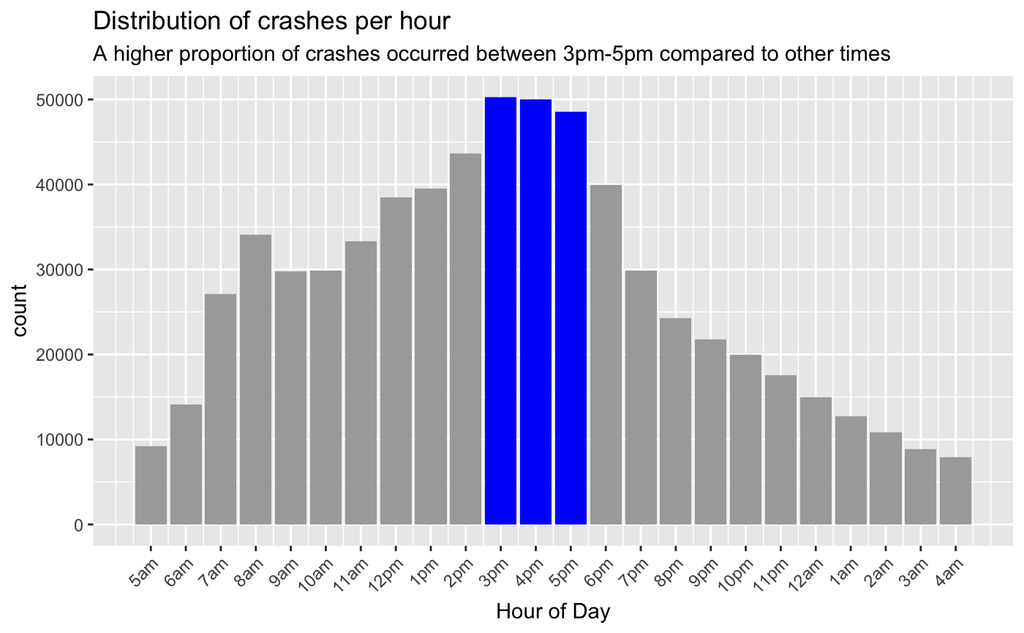

```r
traffic_crashes2 %>%
  ggplot() +
  geom_bar(aes(x = new_hour, fill = factor(new_hour %in% c(15:17)))) +
  scale_fill_manual(values = c("FALSE" = "darkgrey", "TRUE" = "blue")) +
  scale_x_continuous(breaks = seq(5, 28, by = 1), labels = c("5am", "6am", "7am", "8am", "9am", "10am", "11am", "12pm", "1pm", "2pm", "3pm", "4pm", "5pm", "6pm", "7pm", "8pm", "9pm", "10pm", "11pm", "12am", "1am", "2am", "3am", "4am")) +
  labs(
    title = "Distribution of crashes per hour",
    subtitle = "A higher proportion of crashes occurred between 3pm-5pm compared to other times",
    x = "Hour of Day"
  ) +
  theme(legend.position  = "none",
        axis.text.x = element_text(angle = 45, hjust = 1))
```

#2. What are the patterns around the crashes and the days of the week? #Findings: A higher number of crashes take place on Friday, followed by Saturday

```r
traffic_crashes2 %>%
  group_by(wday(CRASH_DAY_OF_WEEK, label = T)) %>%
  summarise(n = n()) %>%
  mutate(prop = n/sum(n)) %>%
  arrange(desc(n))
```

| wday(CRASH_DAY_OF_WEEK, label = T) | n | prop |
| --- | --- | --- |
| Fri | 106529 | 0.1622248 |
| Sat | 97422 | 0.1483565 |
| Thu | 94312 | 0.1436205 |
| Tue | 93113 | 0.1417946 |
| Wed | 92307 | 0.1405673 |
| Mon | 90378 | 0.1376297 |
| Sun | 82614 | 0.1258065 |

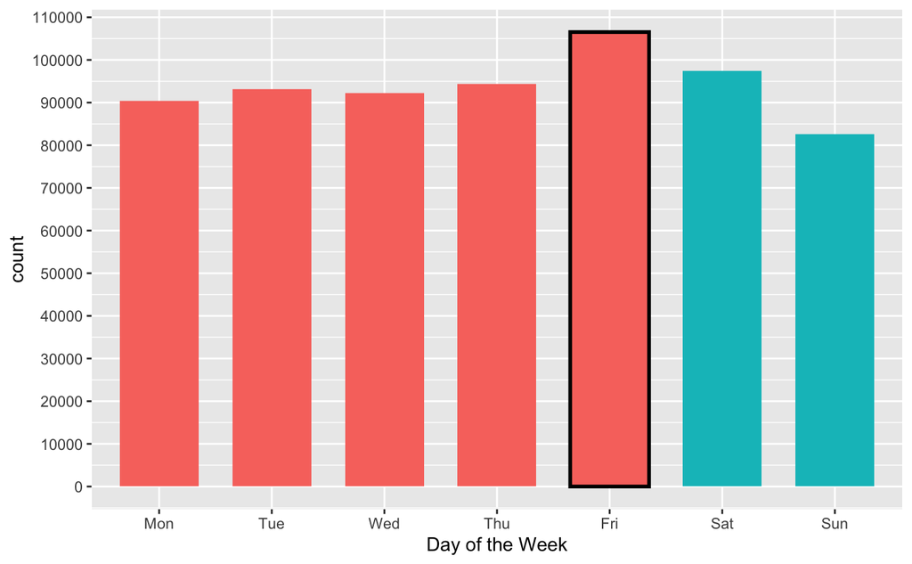

```r
traffic_crashes2 %>%
  ggplot() +
  geom_bar(aes(wday(CRASH_DAY_OF_WEEK, label = T, week_start = 1), fill = factor(CRASH_DAY_OF_WEEK %in% c(7, 1))), width = 0.7, stat = "count") +
  geom_bar(data = subset(traffic_crashes2, wday(CRASH_DAY_OF_WEEK) == 6),
           aes(wday(CRASH_DAY_OF_WEEK, label = T, week_start = 1)), fill = "transparent", color = "black", size =1, width = 0.7, stat = "count") +
  scale_y_continuous(breaks = seq(0, 140000, by = 10000)) +
  labs(x = "Day of the Week") +
  theme(legend.position = "none")
```

#3. What patterns are there for the time of day according to if it is a weekend or a weekday? #Findings: Crashes are higher during the weekend particuarly between 7pm to 4am. Crashes are higher for the weekday between 5am to 11am and between 1pm and 7pm

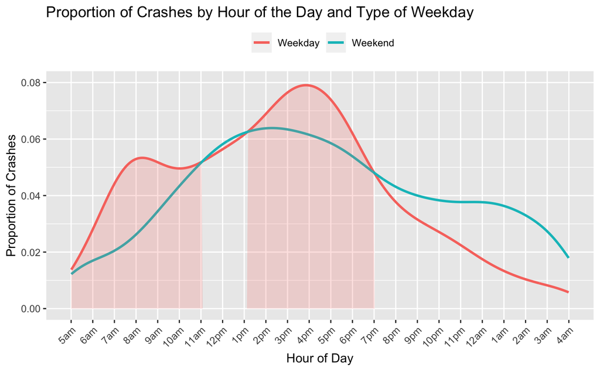

# 4a. At what speed do most crashes occur?

# A large majoirty of the crashes recorded (74%) have been posted by the attending police office at a speed of 30

```r
traffic_crashes2 %>% group_by(POSTED_SPEED_LIMIT) %>%
  summarise(n = n()) %>%
  mutate(prop = round(n / sum(n) * 100,1)) %>%
  arrange(desc(n))
```

| POSTED_SPEED_LIMIT | n | prop |
| --- | --- | --- |
| 30 | 482685 | 73.5 |
| 35 | 44163 | 6.7 |
| 25 | 42409 | 6.5 |
| 20 | 28268 | 4.3 |
| 15 | 23835 | 3.6 |
| 10 | 15967 | 2.4 |
| 40 | 6439 | 1.0 |
| 45 | 4446 | 0.7 |
| 0 | 3878 | 0.6 |
| 5 | 3258 | 0.5 |

[output cut: 31 more lines]

#4b. What is the distribution of crashes excluding 30? # speed limit of 30 has been excluded as it makes up 74% of the crashes and hence makes it difficult to observe any patterns among the other reported speeds

#Findings: The number of crashes tend to increase as the speed limit increases up to 35, however the rate of crashes declines after this

#**** wanted to add a trend line just from 0 to 35 but can’t figure it out ****

```r
traffic_crashes2 %>% group_by(POSTED_SPEED_LIMIT) %>%
  filter(POSTED_SPEED_LIMIT != 30) %>%
  summarise(n = n()) %>%
  mutate(prop = round(n / sum(n) * 100,1)) %>%
  arrange(desc(n))
```

| POSTED_SPEED_LIMIT | n | prop |
| --- | --- | --- |
| 35 | 44163 | 25.4 |
| 25 | 42409 | 24.4 |
| 20 | 28268 | 16.2 |
| 15 | 23835 | 13.7 |
| 10 | 15967 | 9.2 |
| 40 | 6439 | 3.7 |
| 45 | 4446 | 2.6 |
| 0 | 3878 | 2.2 |
| 5 | 3258 | 1.9 |
| 55 | 645 | 0.4 |

[output cut: 30 more lines]

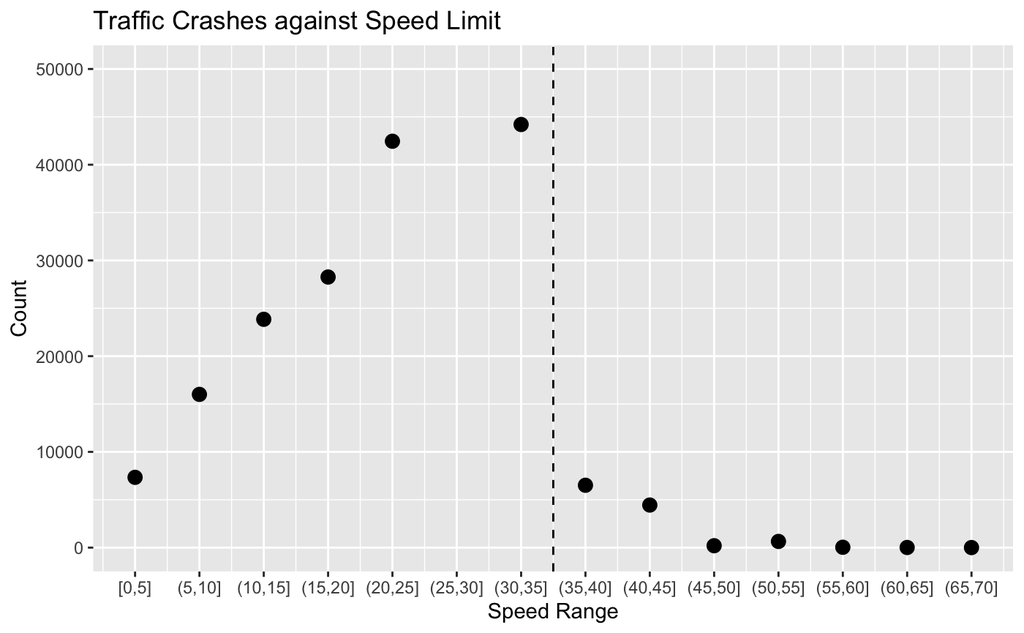

```r
traffic_crashes2 <- traffic_crashes2 %>%
  mutate(
    speed_range = cut_width(POSTED_SPEED_LIMIT, width = 5, start = 0, boundary = 0))

traffic_crashes2 %>%
  group_by(speed_range) %>%
  summarise(n = n()) %>%
  ggplot(aes(x = as.numeric(speed_range), y = n)) +
  geom_point(size = 3) +
  geom_vline(xintercept = 7.5, color = "black", linetype = "dashed") +
  scale_y_continuous(limits = c(0, 50000)) +
  scale_x_continuous(breaks = as.numeric(unique(traffic_crashes2_level$speed_range)),
                     labels = unique(traffic_crashes2_level$speed_range)) +
  labs(title = "Traffic Crashes against Speed Limit", x = "Speed Range", y = "Count")
```

```r
NA
NA
```

[output not shown]

[output cut: 4 more lines]

```r
traffic_crashes2_speedplus35 <- traffic_crashes2 %>%
  filter(POSTED_SPEED_LIMIT > 35) %>%
  group_by(TRAFFICWAY_TYPE) %>%
  summarise(n = n()) %>%
  ungroup() %>%
  mutate(prop = round(n / sum(n), 2))
traffic_crashes2_speedplus35
```

| TRAFFICWAY_TYPE | n | prop |
| --- | --- | --- |
| ALLEY | 2 | 0.00 |
| CENTER TURN LANE | 50 | 0.00 |
| DIVIDED - W/MEDIAN (NOT RAISED) | 1098 | 0.09 |
| DIVIDED - W/MEDIAN BARRIER | 7447 | 0.63 |
| DRIVEWAY | 4 | 0.00 |
| FIVE POINT, OR MORE | 10 | 0.00 |
| FOUR WAY | 328 | 0.03 |
| L-INTERSECTION | 2 | 0.00 |
| NOT DIVIDED | 991 | 0.08 |
| NOT REPORTED | 4 | 0.00 |

[output cut: 10 more lines]

```r
traffic_crashes2_speedless35 <- traffic_crashes2 %>%
  filter(POSTED_SPEED_LIMIT <= 35) %>%
  group_by(TRAFFICWAY_TYPE) %>%
  summarise(n = n()) %>%
  ungroup() %>%
  mutate(prop = round(n / sum(n),2))
traffic_crashes2_speedless35
```

| TRAFFICWAY_TYPE | n | prop |
| --- | --- | --- |
| ALLEY | 11048 | 0.02 |
| CENTER TURN LANE | 4617 | 0.01 |
| DIVIDED - W/MEDIAN (NOT RAISED) | 99123 | 0.15 |
| DIVIDED - W/MEDIAN BARRIER | 29538 | 0.05 |
| DRIVEWAY | 2104 | 0.00 |
| FIVE POINT, OR MORE | 1062 | 0.00 |
| FOUR WAY | 48242 | 0.07 |
| L-INTERSECTION | 157 | 0.00 |
| NOT DIVIDED | 283040 | 0.44 |
| NOT REPORTED | 533 | 0.00 |

[output cut: 10 more lines]

```r
traffic_crashes2_speedplus35 %>% right_join(traffic_crashes2_speedless35, by = "TRAFFICWAY_TYPE", suffix = c("_above_35", "_below_35")) %>%
  arrange(desc(prop_above_35)) %>%
  select(TRAFFICWAY_TYPE, prop_above_35, prop_below_35)
```

| TRAFFICWAY_TYPE | prop_above_35 | prop_below_35 |
| --- | --- | --- |
| DIVIDED - W/MEDIAN BARRIER | 0.63 | 0.05 |
| DIVIDED - W/MEDIAN (NOT RAISED) | 0.09 | 0.15 |
| NOT DIVIDED | 0.08 | 0.44 |
| OTHER | 0.06 | 0.03 |
| ONE-WAY | 0.05 | 0.13 |
| FOUR WAY | 0.03 | 0.07 |
| RAMP | 0.02 | 0.00 |
| T-INTERSECTION | 0.02 | 0.01 |
| UNKNOWN | 0.01 | 0.01 |
| ALLEY | 0.00 | 0.02 |

[output cut: 10 more lines]

```r
NA
```

#6. What is the split of crash type for each speed limit range #Like the previous question, the range is limited to reduce the skew from the numerous values from a speed limit of 30

#Findings: Across all speed ranges, most of the crashes caused no injury or required the car to be towed. However, the chart indicates that the proportion of crashes that did result in injury and/or towing increases as the speed increases - this is explored in the next question

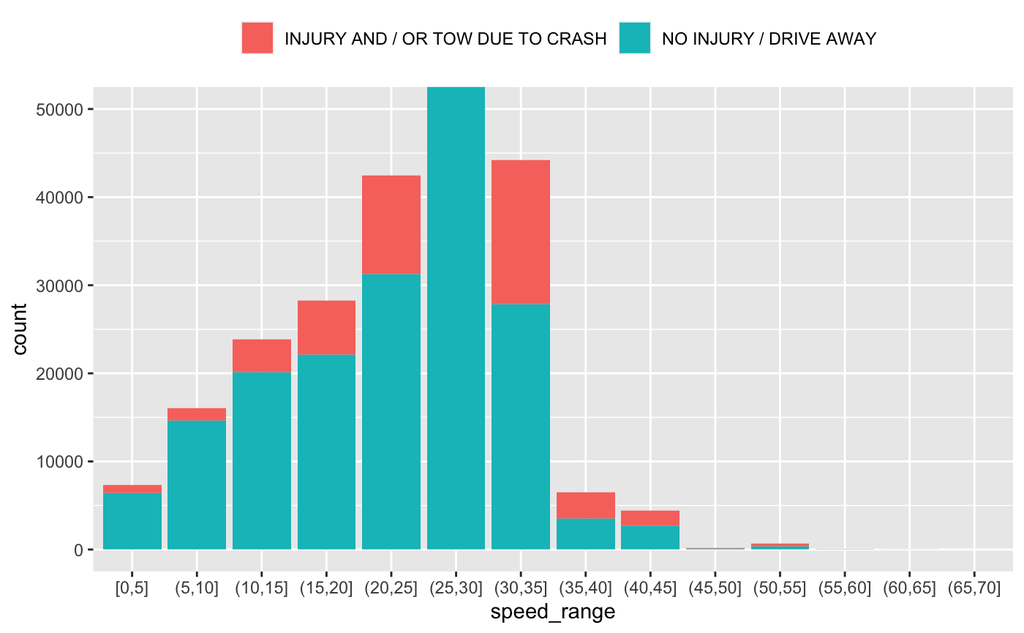

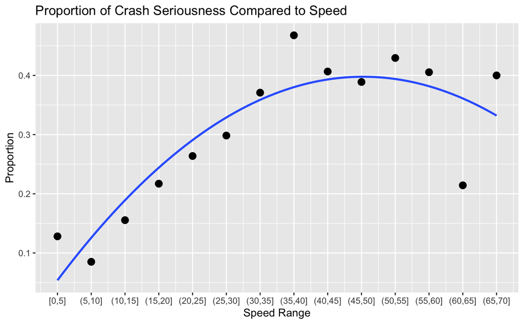

#8. What is the distribution between the device condition and the number of crashes? #Findings: Most of the crashes occur where there are no controls present, however, among the devices which are present, the condition tends to be functioning properly

| DEVICE_CONDITION | n | prop |
| --- | --- | --- |
| NO CONTROLS | 404544 | 0.5730312250 |
| FUNCTIONING PROPERLY | 242602 | 0.3436425241 |
| UNKNOWN | 47793 | 0.0676981523 |
| OTHER | 5517 | 0.0078147575 |
| FUNCTIONING IMPROPERLY | 3161 | 0.0044775147 |
| NOT FUNCTIONING | 2026 | 0.0028698022 |
| WORN REFLECTIVE MATERIAL | 248 | 0.0003512887 |
| MISSING | 81 | 0.0001147354 |

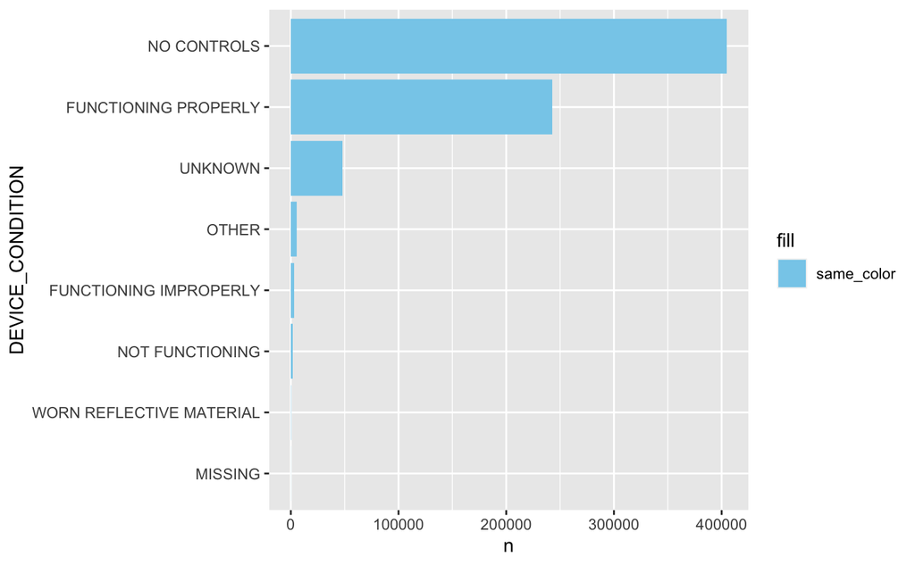

```r
traffic_crashes1 %>%
  group_by(DEVICE_CONDITION) %>%
  summarise(n = n()) %>%
  arrange(n) %>%
  mutate(DEVICE_CONDITION = factor(DEVICE_CONDITION, levels = DEVICE_CONDITION)) %>%
  ggplot() +
  geom_col(aes(x = DEVICE_CONDITION, y = n, fill = "same_color")) +
  coord_flip() +
  scale_fill_manual(values = "skyblue")
```

#9. Out of the devices that are functioning properly, what type of devices are used and what pattern do they have with the number of crashes? #Findings: The main traffic control device present in these cases is the Traffic Signal (Traffic Light), 73%, followed by the Stop Sign/Flasher, 23%, hence the majority of these crashes occur at Traffic Light and Stop Sign Controls

```r
options(scipen = 999)

traffic_crashes1 %>%
  filter(DEVICE_CONDITION == "FUNCTIONING PROPERLY") %>%
  group_by(TRAFFIC_CONTROL_DEVICE) %>%
  summarise(n = n()) %>%
  mutate(prop = round(n/sum(n),2)) %>%
  arrange(desc(n))
```

| TRAFFIC_CONTROL_DEVICE | n | prop |
| --- | --- | --- |
| TRAFFIC SIGNAL | 177774 | 0.73 |
| STOP SIGN/FLASHER | 55582 | 0.23 |
| NO CONTROLS | 3289 | 0.01 |
| OTHER | 1793 | 0.01 |
| LANE USE MARKING | 668 | 0.00 |
| UNKNOWN | 558 | 0.00 |
| OTHER REG. SIGN | 535 | 0.00 |
| YIELD | 503 | 0.00 |
| OTHER WARNING SIGN | 446 | 0.00 |
| RAILROAD CROSSING GATE | 341 | 0.00 |

[output cut: 9 more lines]